# Homework 7

## Problem #1: Estimating Quantiles (8 pts; 2pts each)

There are 9 algorithms in R to estimate population quantiles. Type `?quantile` to read about them. Here we will investigate the variance of some of these estimators. To use the quantile function you use the syntax `quantile(vector, probs, type)`. For example if you have data in a vector called `sampleData` and you wish to estimate the 80th percentile using algorithm 7 (the default), you use `quantile(sampleData, .80, type=7)`

Suppose we’re interested in the 95th percentile for $X$, and we know that $X$ follows a uniform distribution. We want to randomly sample $n=30$ values and estimate the 95th percentile. Using MC simulation estimate the following:

1. Which quantile algorithm (4 through 9) has the smallest absolute bias ($|\hat{\theta}-\theta|$)? *Hint: you can use $unif(0,1)$ for the purposes of this estimation, as your answer won’t depend on the upper and lower bounds chosen.*

For $\mathcal{U}[0, 1]$ we know the 95th percentile to truly be $.95$:

```r
set.seed(123)
starting_sample = runif(30, 0, 1)
point_est = quantile(starting_sample, .95, type = 4)
mean_bias = c()
for (type in 4:9) {
  bias = c()
  for (i in 1:1e3) {
    sample_data = runif(30, 0, 1)
    point_est_mc = quantile(sample_data, .95, type = type, names = FALSE)
    bias = append(bias, abs(.95 - point_est_mc))
  }
  print(paste("bias for:", type))
  print(mean(bias))
  mean_bias = append(mean_bias, mean(bias))
}
```

```
## [1] "bias for: 4"
## [1] 0.04127
## [1] "bias for: 5"
## [1] 0.03302889
## [1] "bias for: 6"
## [1] 0.02691573
## [1] "bias for: 7"
## [1] 0.03722469
## [1] "bias for: 8"
## [1] 0.02985434
## [1] "bias for: 9"
## [1] 0.03187468
```

```r
print(paste("smallest bias:", min(mean_bias)))
```

```
## [1] "smallest bias: 0.0269157252223115"
```

Type 6 has the smallest.

2. Which quantile algorithm (4 through 9) has the smallest variance?

```r
set.seed(123)
starting_sample = runif(30, 0, 1)
point_est = quantile(starting_sample, .95, type = 4)
percentile = c()
mean_var = c()
for (type in 4:9) {
  percentile = c()
  for (i in 1:1e3) {
    sample_data = runif(30, 0, 1)
    point_est_mc = quantile(sample_data, .95, type = type, names = FALSE)
    percentile = append(percentile, point_est_mc)
  }
  print(paste("variance for:", type))
  print(var(percentile))
  mean_var = append(mean_var, var(percentile))
}
```

```
## [1] "variance for: 4"
## [1] 0.002038784
## [1] "variance for: 5"
## [1] 0.001950684
## [1] "variance for: 6"
## [1] 0.001198392
## [1] "variance for: 7"
## [1] 0.001986757
## [1] "variance for: 8"
## [1] 0.001616476
## [1] "variance for: 9"
## [1] 0.001695616
```

```r
print(paste("smallest var:", min(mean_var)))
```

```
## [1] "smallest var: 0.00119839180090103"
```

Type 6 has the smallest.

3. Which method is best for estimating the 95th percentile from a uniform distribution? Justify your answer.

The least biased estimator is 6, and the most consistent estimator is 6. From these statistics it seems plausible 6 is the most accurate and most consistent estimator, making it the best here for the uniform.

4. What about if $X\sim N(\mu, \sigma^2)$? Would you prefer a different method for estimating the 95th percentile from a normal distribution? *Hint: repeat the same analysis for $N(0,1)$.*

```r
set.seed(123)
starting_sample = runif(30, 0, 1)
point_est = quantile(starting_sample, .95, type = 4)
percentile = c()
mean_var = c()
for (type in 4:9) {
  percentile = c()
  for (i in 1:1e3) {
    sample_data = rnorm(30, 0, 1)
    point_est_mc = quantile(sample_data, .95, type = type, names = FALSE)
    percentile = append(percentile, point_est_mc)
  }
  print(paste("variance for:", type))
  print(var(percentile))
  mean_var = append(mean_var, var(percentile))
}
```

```
## [1] "variance for: 4"
## [1] 0.1075616
## [1] "variance for: 5"
## [1] 0.1341833
## [1] "variance for: 6"
## [1] 0.1484836
## [1] "variance for: 7"
## [1] 0.1038427
## [1] "variance for: 8"
## [1] 0.1432893
## [1] "variance for: 9"
## [1] 0.1308418
```

```r
print(paste("smallest var:", min(mean_var)))
```

```
## [1] "smallest var: 0.103842684759717"
```

```r
set.seed(123)
starting_sample = runif(30, 0, 1)
point_est = quantile(starting_sample, .95, type = 4)
mean_bias = c()
for (type in 4:9) {
  bias = c()
  for (i in 1:1e3) {
    sample_data = rnorm(30, 0, 1)
    point_est_mc = quantile(sample_data, .95, type = type, names = FALSE)
    bias = append(bias, abs(.95 - point_est_mc))
  }
  print(paste("bias for:", type))
  print(mean(bias))
  mean_bias = append(mean_bias, mean(bias))
}
```

```
## [1] "bias for: 4"
## [1] 0.5461244
## [1] "bias for: 5"
## [1] 0.689245
## [1] "bias for: 6"
## [1] 0.8559925
## [1] "bias for: 7"
## [1] 0.5542893
## [1] "bias for: 8"
## [1] 0.7635281
## [1] "bias for: 9"
## [1] 0.7207356
```

```r
print(paste("smallest bias:", min(mean_bias)))
```

```
## [1] "smallest bias: 0.5461244006317"
```

We can see that 7 is the most consistent estimator and 4 is the least biased when estimating from the normal. Depending on the use case of the estimator, either is preferable over 6.

## Problem #2: Estimating a Geometric $p$ (6 pts; 2 pts each)

1. Use the method of moments to come up with an estimator for a geometric distributions parameter $p$. *Hint: Use the fact that if $X\sim Geom(p)$ then $EX=\frac{1-p}{p}*$.

$EX=\frac{1-p}{p} = \frac{1}{p} - 1$, then $(EX + 1)^{-1} = p$.

2. Estimate the sampling distribution of this estimator when we sample $n=13$ values from from $Geom(.15)$. Show the histogram of the estimated sampling distribution.

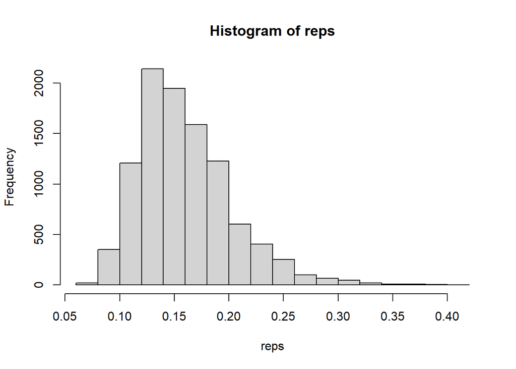

```r
reps = replicate(1e4, 1 / (1 + mean(rgeom(13, .15))))
hist(reps)
```

3. Estimate the bias of this estimator. Is it biased? If it is biased how would you modify it so that you could create an unbiased estimator?

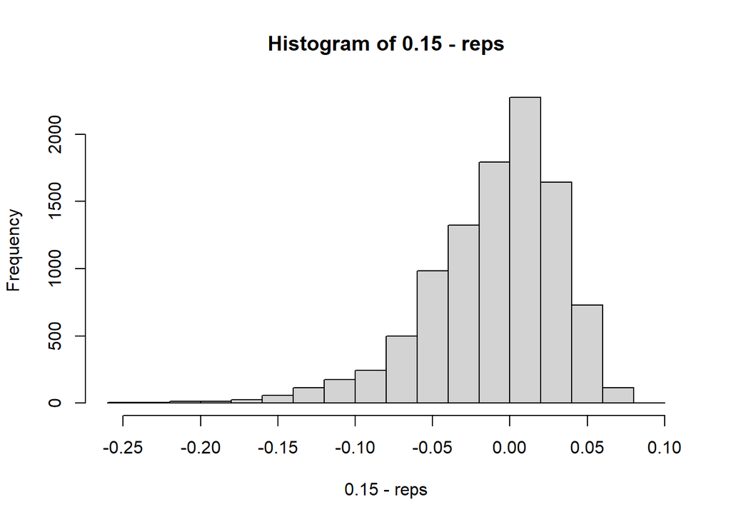

```r
hist(.15 - reps)
```

```r
mean(.15 - reps)
```

```
## [1] -0.009836052
```

There is a negative bias, the distribution of the bias seems to indicate a left skew, so adding a term to cancel it would improve bias.

## Problem #3: Estimating $\lambda$ from a Poisson Distribution(8 pts; 2 pts each)

It is interesting that if $X\sim Pois(\lambda)$ that $EX=VarX=\lambda$. One could use either $\bar{X}$ or $S^2$ as an estimator of $\lambda$ perhaps.

1. Using $n=15$ and $\lambda=20$ for this problem, use MC simulation to estimate the sampling distribution of The estimator $\bar{X}$. Show its histogram.

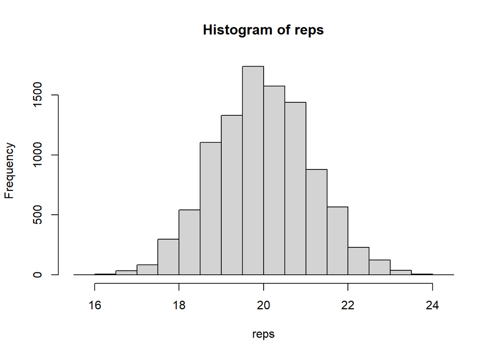

```r
reps = replicate(1e4, mean(rpois(15, 20)))
hist(reps)
```

2. Repeat the same but this time use $S^2$.

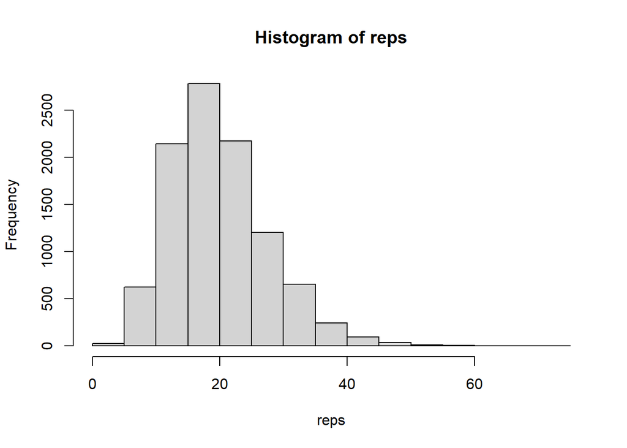

```r
reps = replicate(1e4, var(rpois(15, 20)))
hist(reps)
```

3. Compare the two estimators. Would you prefer one over the other? Why?

$\bar{X}$ is preferable since it isn’t skewed like $S^2$, $S^2$ also has a much wider range, so the estimations from $S^2$ aren’t as reliable.

4. What about a linear combination of the two variables? Could you construct an estimator of $\lambda$ of the form $a\bar{X} + bS^2$ that would be better than using either of them by themselves?

We can, but we would have to have $b = 0$ notice that both estimators should produce $\lambda$, but due to the nonlinearity of $S^2$, its results are too varied in practice to be better than simply using $\bar{X}$.

## Problem #4: The Standard Error of $\bar{X}$(8 pts; 2 pts each)

What would be the required sample size $n$ so that the standard error of $\bar{X}$ (i.e. $SD(\bar{X})$) would be 2 (or just under 2) for the following populations:

$Var(\bar{X}) = \frac{Var(X)}{n}$ then $SD(\bar{X}) = \sqrt{\frac{Var(X)}{n}}$.

1. $Normal(1000, 10^2)$

$$\sqrt{\frac{Var(X)}{n}} \rightarrow
\sqrt{\frac{10^2}{n}} <= 2$$

$$10^2 <= 4n, n >= 25$$

At least $25$ samples.

2. $Pois(75)$

$$\sqrt{\frac{Var(X)}{n}} \rightarrow
\sqrt{\frac{75}{n}} <= 2$$

$$75 <= 4n, n >=
\frac{75}{4}$$

At least $19$ samples.

3. $Binom(200, .35)$

$$\sqrt{\frac{Var(X)}{n}} \rightarrow
\sqrt{\frac{200(.35)(.65)}{n}} <= 2$$

$$45.5 <= 4n, n >=
\frac{45.5}{4}$$

At least $12$ samples.

4. $exp(.05)$

$$\sqrt{\frac{Var(X)}{n}} \rightarrow
\sqrt{\frac{20^2}{n}} <= 2$$

$$400 <= 4n, n >=
\frac{400}{4}$$

At least 100 samples.